# Practical Machine Learning - Course Project

Maria D’Angelo

## Introduction

The goal of this assignment is to build a predictive model to determine how well a particular exercise (Unilateral Dumbbell Biceps Curl) is done based on readings from a number of accelerometers. The model wast rained on a data set containing the measures from accelerometers on the belt, forearm, arm, and dumbbell. The data set contains the measures for 6 male participants (aged 20-28 years) as they performed the exercise using a 1.25 kg dumbbell. Each participant performed the exercise 10 times in the correct manner, as well as 10 times for each of 5 ways of doing the exercise incorrectly. More information regarding the data set can be found [here](http://groupware.les.inf.puc-rio.br/har).

## Downloading and loading the data into R

```r
setwd("~/Dropbox/RTutorials/Coursera8-PracticalMachineLearning/C8_PracMachLearn/")

if (! file.exists('data/pml-training.csv')) {
    download.file('http://d396qusza40orc.cloudfront.net/predmachlearn/pml-training.csv', destfile = 'data/pml-training.csv')
}
if (! file.exists('data/pml-testing.csv')) {
    download.file('http://d396qusza40orc.cloudfront.net/predmachlearn/pml-testing.csv', destfile = 'data/pml-testing.csv')
}
pml_training <- read.csv("data//pml-training.csv")
pml_testing <- read.csv("data//pml-testing.csv")
```

## Exploring the data

First I determined how many variables were included in the data set (160), and took a look at the first few lines of the data. As is evident, there are many variables that are missing values in most of the observations (for space I have suppressed the code for the summary of the training data). Based on the description of the project and the data set acquisition described on the [Human Activity Recognition website](http://groupware.les.inf.puc-rio.br/har), I decided to only include variables that are measurements from the accelerometer, discarding the remaining variables. This left me with 52 predictor variables (plus the dependent variable, ‘classe’).

```r
dim(pml_training)
```

```
## [1] 19622   160
```

```r
#summary(pml_training)

inc_vars<- c('roll_belt', 'pitch_belt', 'yaw_belt', 'total_accel_belt',
             'gyros_belt_x', 'gyros_belt_y', 'gyros_belt_z',
             'accel_belt_x', 'accel_belt_y', 'accel_belt_z',
             'magnet_belt_x', 'magnet_belt_y', 'magnet_belt_z',
             'roll_arm', 'pitch_arm', 'yaw_arm', 'total_accel_arm',
             'gyros_arm_x', 'gyros_arm_y', 'gyros_arm_z',
             'accel_arm_x', 'accel_arm_y', 'accel_arm_z',
             'magnet_arm_x', 'magnet_arm_y', 'magnet_arm_z',
             'roll_dumbbell', 'pitch_dumbbell', 'yaw_dumbbell', 'total_accel_dumbbell',
             'gyros_dumbbell_x', 'gyros_dumbbell_y', 'gyros_dumbbell_z',
             'accel_dumbbell_x', 'accel_dumbbell_y', 'accel_dumbbell_z',
             'magnet_dumbbell_x', 'magnet_dumbbell_y', 'magnet_dumbbell_z',
             'roll_forearm', 'pitch_forearm', 'yaw_forearm', 'total_accel_forearm',
             'gyros_forearm_x', 'gyros_forearm_y', 'gyros_forearm_z',
             'accel_forearm_x', 'accel_forearm_y', 'accel_forearm_z',
             'magnet_forearm_x', 'magnet_forearm_y', 'magnet_forearm_z')

training_redVar <- pml_training[, c(inc_vars, "classe")]
testing_redVar <- pml_testing[, inc_vars]

dim(training_redVar)
```

```
## [1] 19622    53
```

To get a sense of how the different variables relate to one another, I calculated the correlation between the various measures and plotting any correlations that were greater than 0.5 or less than -0.5 using ggplot.

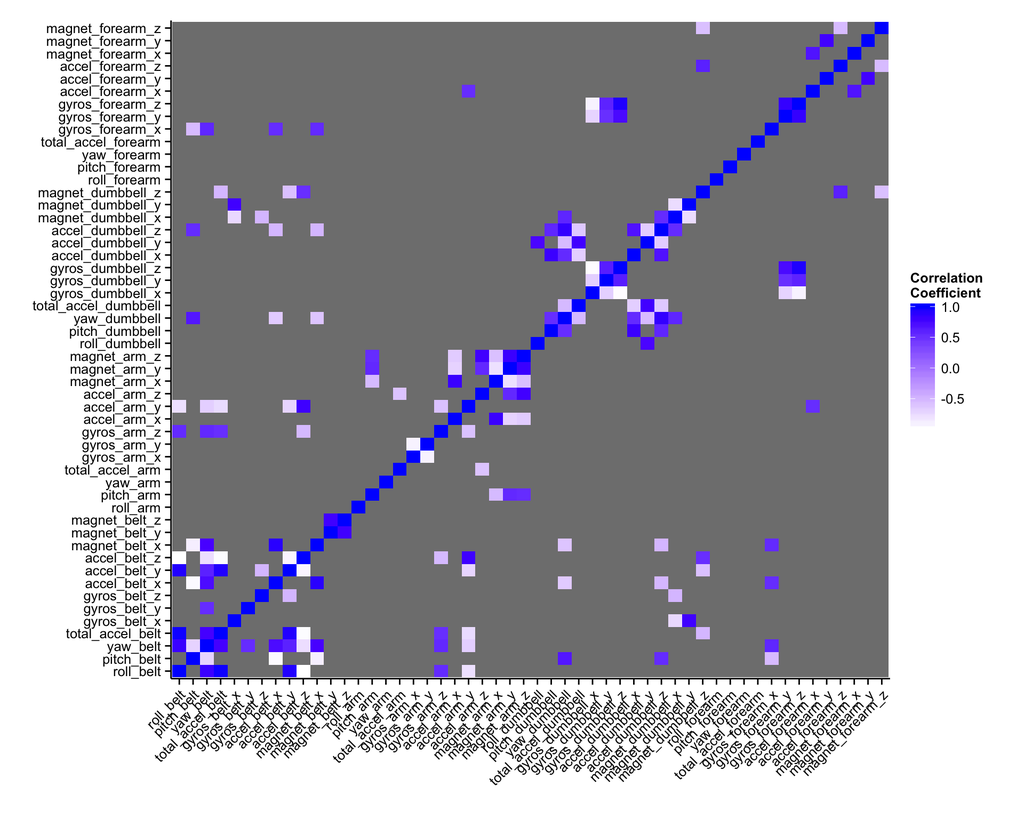

```r
var_cor <- cor(training_redVar[, 1:52])
library(reshape2); library(ggplot2)
correlations <- melt(var_cor)

correlations$value2 <- ifelse(abs(correlations$value) < .5, NA, correlations$value)

ggplot(correlations, aes(y=Var1, x=Var2)) +
    geom_tile(aes(fill=value2)) +
    scale_fill_gradient(low="white", high="blue", name = "Correlation\nCoefficient") +
    xlab("") + ylab("") + theme_classic() +
    theme(axis.text.x = element_text(angle = 45, hjust = 1))
```

## Predictive Model

Given that the outcome variable is categorical and that the relations among the outcome and predictors is non-linear, I decided to create random forest models. Random forest models use bootstrapping to select a subset of candidate variables at each split. I decided to use random forest models as they are typically among the top performing algorithms in prediction contests. I used the `randomForest` package in R, and although there are many arguments that can been adjusted in the function call, for the present assignment I varied the value of `mtry` to select my model, with my final model using `mtry = 9`, as it produced the lowest estimate of OOB (0.26%) in my tests. `mtry` is the number of variables randomly sampled as candidates at each split. The results of my model testing is listed in the Appendix.

Random forest models construct trees by using bootstrapping in which each tree is constructed using a subset of the original data. For each tree, the remaining subset of the original data (typically 30% of the data - see [here](https://www.stat.berkeley.edu/~breiman/RandomForests/cc_home.htm#ooberr)) is then classified, and across trees the classification accuracy is averaged to calculate the OOB error estimate.

```r
library(caret); library(randomForest)
set.seed(369)

modFitFinal <- randomForest(training_redVar[,-53], training_redVar$classe, mtry=9)
modFitFinal
```

```
##
## Call:
##  randomForest(x = training_redVar[, -53], y = training_redVar$classe,      mtry = 9)
##                Type of random forest: classification
##                      Number of trees: 500
## No. of variables tried at each split: 9
##
##         OOB estimate of  error rate: 0.26%
## Confusion matrix:
##      A    B    C    D    E  class.error
## A 5577    2    0    0    1 0.0005376344
## B   11 3783    3    0    0 0.0036871214
## C    0   10 3412    0    0 0.0029222677
## D    0    0   17 3198    1 0.0055970149
## E    0    0    2    4 3601 0.0016634322
```

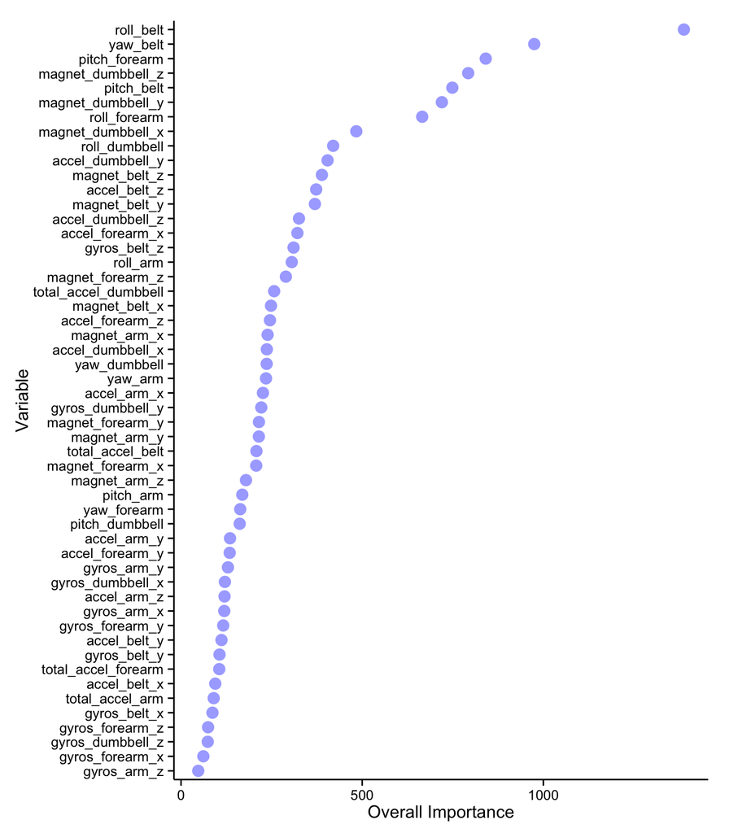

```r
imp <- varImp(modFitFinal)
imp$Variable <- row.names(imp)
imp <- imp[order(imp$Overall, decreasing = T),]
ggplot(imp, aes(x = reorder(Variable, Overall), y = Overall, group =1)) + theme_classic() +
    coord_flip() + geom_point(colour = "blue", alpha = .40, size = 4) +
    xlab("Variable") + ylab("Overall Importance")
```

A graph of overall importance shows that the roll belt variable was the most important variable in training the random forest model. A cluster of other variables had high importance, including yaw-belt, pitch forearm, etc. Future work should examine how well models do that only include a subset of the variables, to determine whether all 52 included variables are needed for accurate prediction of classe.

## Fit on test data

My model was 100% accurate in predicting the `classe` variable for the test set, which is consistent with the low class error and OOB estimate (0.26%) of the final model.

```r
test_fit <- predict(modFitFinal, testing_redVar)

write_sub_files = function(x){
  n = length(x)
  for(i in 1:length(x)){
    filename = paste0("problem_id_",i,".txt")
    write.table(x[i],file=filename,quote=FALSE,row.names=FALSE,col.names=FALSE)
  }
}

write_sub_files(test_fit)
```

## Appendix

```r
set.seed(369)
modFit <- randomForest(training_redVar[,-53], training_redVar$classe)
modFit
```

```
##
## Call:
##  randomForest(x = training_redVar[, -53], y = training_redVar$classe)
##                Type of random forest: classification
##                      Number of trees: 500
## No. of variables tried at each split: 7
##
##         OOB estimate of  error rate: 0.3%
## Confusion matrix:
##      A    B    C    D    E  class.error
## A 5577    3    0    0    0 0.0005376344
## B    9 3783    5    0    0 0.0036871214
## C    0   10 3410    2    0 0.0035067212
## D    0    0   21 3193    2 0.0071517413
## E    0    0    2    5 3600 0.0019406709
```

```r
modFit6T <- randomForest(training_redVar[,-53], training_redVar$classe, mtry=6)
modFit6T
```

```
##
## Call:
##  randomForest(x = training_redVar[, -53], y = training_redVar$classe,      mtry = 6)
##                Type of random forest: classification
##                      Number of trees: 500
## No. of variables tried at each split: 6
##
##         OOB estimate of  error rate: 0.3%
## Confusion matrix:
##      A    B    C    D    E  class.error
## A 5578    2    0    0    0 0.0003584229
## B   10 3784    3    0    0 0.0034237556
## C    0   12 3407    3    0 0.0043834015
## D    0    0   19 3194    3 0.0068407960
## E    0    0    0    6 3601 0.0016634322
```

```r
modFit5T <- randomForest(training_redVar[,-53], training_redVar$classe, mtry=5)
modFit5T
```

```
##
## Call:
##  randomForest(x = training_redVar[, -53], y = training_redVar$classe,      mtry = 5)
##                Type of random forest: classification
##                      Number of trees: 500
## No. of variables tried at each split: 5
##
##         OOB estimate of  error rate: 0.31%
## Confusion matrix:
##      A    B    C    D    E  class.error
## A 5578    2    0    0    0 0.0003584229
## B   10 3784    3    0    0 0.0034237556
## C    0   12 3410    0    0 0.0035067212
## D    0    0   25 3189    2 0.0083955224
## E    0    0    1    5 3601 0.0016634322
```

```r
modFit8T <- randomForest(training_redVar[,-53], training_redVar$classe, mtry=8)
modFit8T
```

```
##
## Call:
##  randomForest(x = training_redVar[, -53], y = training_redVar$classe,      mtry = 8)
##                Type of random forest: classification
##                      Number of trees: 500
## No. of variables tried at each split: 8
##
##         OOB estimate of  error rate: 0.3%
## Confusion matrix:
##      A    B    C    D    E  class.error
## A 5577    2    0    0    1 0.0005376344
## B   10 3784    3    0    0 0.0034237556
## C    0   10 3409    3    0 0.0037989480
## D    0    0   21 3193    2 0.0071517413
## E    0    0    1    5 3601 0.0016634322
```

```r
modFit9T <- randomForest(training_redVar[,-53], training_redVar$classe, mtry=9)
modFit9T
```

```
##
## Call:
##  randomForest(x = training_redVar[, -53], y = training_redVar$classe,      mtry = 9)
##                Type of random forest: classification
##                      Number of trees: 500
## No. of variables tried at each split: 9
##
##         OOB estimate of  error rate: 0.26%
## Confusion matrix:
##      A    B    C    D    E  class.error
## A 5579    1    0    0    0 0.0001792115
## B    9 3786    2    0    0 0.0028970240
## C    0   11 3410    1    0 0.0035067212
## D    0    0   17 3197    2 0.0059079602
## E    0    0    1    7 3599 0.0022179096
```